# Twelve‐year trends in pharmacologic treatment of type 2 diabetes among patients with heart failure in the United States - Dawwas - 2020 - Diabetes, Obesity and Metabolism - Wiley Online Library

[Diabetes, Obesity and Metabolism](https://dom-pubs.onlinelibrary.wiley.com/journal/14631326)

[Volume 22, Issue 4](https://dom-pubs.onlinelibrary.wiley.com/toc/14631326/2020/22/4) p. 705-710

[figure not shown]

BRIEF REPORT

Full Access

# Twelve-year trends in pharmacologic treatment of type 2 diabetes among patients with heart failure in the United States

[Ghadeer K. Dawwas PhD](https://dom-pubs.onlinelibrary.wiley.com/action/doSearch?ContribAuthorRaw=Dawwas%2C+Ghadeer+K),

[Charles E. Leonard PharmD](https://dom-pubs.onlinelibrary.wiley.com/action/doSearch?ContribAuthorRaw=Leonard%2C+Charles+E),

[Mahek Garg MS](https://dom-pubs.onlinelibrary.wiley.com/action/doSearch?ContribAuthorRaw=Garg%2C+Mahek),

[Scott M. Vouri PhD](https://dom-pubs.onlinelibrary.wiley.com/action/doSearch?ContribAuthorRaw=Vouri%2C+Scott+M),

[Steven M. Smith PharmD](https://dom-pubs.onlinelibrary.wiley.com/action/doSearch?ContribAuthorRaw=Smith%2C+Steven+M),

[James H. Flory MD](https://dom-pubs.onlinelibrary.wiley.com/action/doSearch?ContribAuthorRaw=Flory%2C+James+H),

[Michael V. Genuardi MD](https://dom-pubs.onlinelibrary.wiley.com/action/doSearch?ContribAuthorRaw=Genuardi%2C+Michael+V),

[Haesuk Park PhD](https://dom-pubs.onlinelibrary.wiley.com/action/doSearch?ContribAuthorRaw=Park%2C+Haesuk),

First published: 05 January 2020

https://doi.org/10.1111/dom.13949

Citations: 2

**Peer Review** The peer review history for this article is available at https://publons.com/publon/10.1111/dom.13949.

**Funding information:** None.

## Abstract

We conducted a cross-sectional analysis using a database from commercial health plans in the United States to describe trends in the use of antidiabetic medications among patients with type 2 diabetes and heart failure (HF) from 2006 through 2017. We used loop diuretic dose as a surrogate for HF severity (mild HF 0-40 mg/day, moderate-severe HF >40 mg/day). We assessed antidiabetic medication dispensing in the 90 days following HF diagnosis. Over the 12-year period, we identified an increase in the use of metformin (39.2% vs. 62.6%), dipeptidyl peptidase-4 inhibitors (DPP-4i) (0.5% vs. 17.1%) and sodium-glucose co-transporter-2 inhibitors (SGLT-2i) (0.0% vs. 9.0%), but a decrease in the use of sulphonylureas (47.8% vs. 27.8%) and thiazolidinediones (TZDs) (31.7% vs. 5.3%). In 2017, patients with moderate-severe HF more commonly used insulin (43.1%); a majority of mild HF patients used metformin (62.8%). A proportion of patients with moderate-severe HF used TZDs (4.4%). Among patients with diabetes and HF, the use of metformin and DPP-4i rapidly increased, but a proportion of patients with moderate-severe HF continued to use TZDs. Despite their promising cardiovascular safety profile, SGLT-2i use remains limited.

## 1 INTRODUCTION

Patients with type 2 diabetes are at a 2-5-fold greater risk of developing heart failure (HF) than those without diabetes.1 The co-existence of both conditions creates a clinical challenge as some antidiabetic drugs are contraindicated in patients with HF, whereas emerging evidence suggests other classes may be preferred.2-4 For example, thiazolidinediones (TZDs) are associated with fluid retention and higher risk of HF, particularly when used concomitantly with insulin.2 Metformin was long considered contraindicated in patients with HF requiring pharmacological treatment, but this contraindication was eliminated in 2006 as evidence of its safety in patients with HF emerged.

In the past decade, several other classes of antidiabetic medications have been approved for the treatment of type 2 diabetes, including dipeptidyl peptidase-4 inhibitors (DPP-4i) and sodium-glucose co-transporter-2 inhibitors (SGLT-2i). Generally heightened awareness of the cardiovascular safety (or lack thereof) of older diabetic pharmacotherapies, combined with evidence from more recent antidiabetic cardiovascular outcome trials, warrant an assessment of these drugs in real-world populations. Unfortunately, data on the utilization of antidiabetic drugs in patients with HF are sparse, with the most recent evidence using data which are now nearly 2 decades old.5 Further, limited data suggest that TZDs are often prescribed in patients with HF.6

Therefore, our objective was to examine the use of antidiabetic medications after the development of HF, overall and stratified by HF severity, over a current 12-year period.

## 2 METHODS

### 2.1 Data source

We used Truven Health Analytics MarketScan, a commercial and Medicare Supplemental claims database (January 2006 to December 2017). The database captures information on outpatient, inpatient, health expenditure, enrolment and prescription drug claims of more than 57 million individuals.

### 2.2 Study design and patient population

We conducted a retrospective cross-sectional analysis among patients aged ≥18 years who had an HF diagnosis (International Classification of Diseases [ICD]-9-CM: 428.x; ICD-10-CM: I50.x) on inpatient discharge or two outpatient diagnoses within 1 year. These codes were found to have a sensitivity of 91% and 90% and a positive predictive value (PPV) of 72% and 69% for ICD-9-CM and ICD-10-CM, respectively.7 We included patients who had a diagnosis of type 2 diabetes during the 12 months preceding their first HF diagnosis (index date) based on the presence of one inpatient or two outpatient diagnoses within 1 year (ICD-9-CM: 250.x0 or 250.x2; ICD-10-CM: E11.x). Diagnosis codes for type 2 diabetes have a sensitivity of 86% and 91% and a PPV of 80% and 97% for ICD-9-CM and ICD-10-CM, respectively.7, 8 Patients were required to have continuous enrolment in medical and pharmacy benefits for ≥12 months prior to, and ≥90 days after, the index date. The baseline period was a 12-month lookback period. We excluded patients with type 1 diabetes as they are more likely to use insulin, and also those with end-stage renal disease, because of contraindications or a need for dose adjustment.9

We categorized HF patients by dosage of oral loop diuretics dispensed in the 90 days after HF diagnosis. We did not require patients to receive a loop diuretics prescription to enter the study cohort in order to capture patients with mild HF who may not receive a prescription of loop diuretics. HF stages were defined based on the following furosemide-equivalent dosages (furosemide 80 mg = torasemide 40 mg = bumetanide 3 mg = ethacrynic acid 50 mg) into: mild HF (0-40 mg/day) and moderate-severe HF (>40 mg/day).10, 11 The use of loop diuretics dosage as a surrogate for HF stages was supported by prior evidence, which found higher loop diuretics dosages (≥40 mg/day) is positively associated with HF severity and consistent congestion.10, 11

### 2.3 Outcome measures

In each year we examined the proportion of patients with diabetes and HF who had one or more pharmacy fills during the 90-day postindex period for each of the different pharmacologic classes of antidiabetic medications, consisting of DPP-4i, TZDs, metformin, sulphonylureas, glucagon-like peptide-1 agonists (GLP1a), SGLT-2i, insulin and others (meglitinides, α-glucosidase inhibitors and amylin analogues).

### 2.4 Analyses

We summarized selected demographics and clinical characteristics across each study year. Because the nature of diabetes treatment means that patients probably concomitantly use medications that belong to more than one class at the same time, we categorized patients into several non-exclusive groups. Trends of antidiabetic medications use were analysed by the Cochrane-Armitage test. In subgroup analyses, we stratified the primary analysis by HF severity, age, sex and diabetes severity (measured using the adaptive diabetes co-morbidity index [aDCSI]). Additionally, we examined the use of co-medications among the entire sample and among TZD users. All analyses were performed using SAS 9.4 (SAS Institute, Cary, NC, USA).

## 3 RESULTS

### 3.1 Patients’ characteristics

We identified 657 331 patients with HF and diabetes between 2006 and 2017 (Figure S1). The overall number of patients identified decreased over time because of fewer insurers contributing data, but the incidence of HF remained stable between 1.5% and 2% across study years. In 2006 and 2017, the mean age was 66.3 vs. 59.0 years and the proportion of males was 52.8% vs. 54.9%, respectively (Table S1).

### 3.2 Utilization of antidiabetic medications

#### 3.2.1 Overall incident HF population

From 2006 to 2017, there was an increase in the use of metformin (39.2% vs. 62.6%) and DPP-4i (0.5% vs. 17.1%), but a decline in the use of sulphonylureas (47.8% vs. 27.8%) and TZDs (31.7% vs. 5.3%). SGLT-2i use also increased between their introduction in 2013 (0.6%) and 2017 (9.0%) (Figure 1 and Table S2). The *P*-value for all trends was <0.0001.

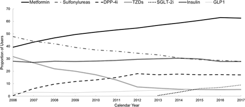

**Figure 1**

Trends in the use of antidiabetic medications among patients with concomitant type 2 diabetes and heart failure, 2006-2017. DPP-4i, dipeptidyl peptidase-4 inhibitors; GLP1, glucagon-like peptide-1 agonists; SGLT-2i, sodium-glucose co-transporter-2 inhibitors; TZDs, thiazolidinediones.*P* <0.0001 for all classes based on results from Cochrane-Armitage test.Groups were not mutually exclusive as patients could have filled a prescription of more than one class. Antidiabetic medication use was assessed during the 90 days following heart failure diagnosis

### 3.3 Subgroup analysis by proxy for HF severity

In 2006, sulphonylureas were the most commonly used class across stages of HF (47.8% for mild and 49.7% for moderate-severe) (Figure 2 and Table S3). However, in 2017, metformin (62.8%) and insulin (43.1%) were the most commonly used among patients with mild and moderate-severe HF, respectively. TZD use dropped precipitously from 2006 (27%-32% prevalence) until about 2013, and stabilized thereafter at ~ 4% to 6% in both mild and moderate-severe HF.

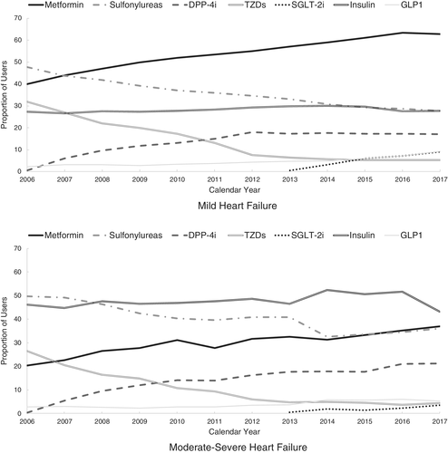

**Figure 2**

Trends in the use of antidiabetic medications among patients with concomitant type 2 diabetes and heart failure, stratified by heart failure severity, 2006-2017. DPP-4i, dipeptidyl peptidase-4 inhibitors; GLP1, glucagon-like peptide-1 agonists; SGLT-2i, sodium-glucose co-transporter-2 inhibitors; TZDs, thiazolidinediones.*P* <0.0001 for all classes based on results from Cochrane-Armitage test.Groups were not mutually exclusive as patients could have filled a prescription of more than one class. Antidiabetic medication use was assessed during the 90 days following heart failure diagnosis

### 3.4 Subgroup analyses by age, sex and aDCSI

Trends in the use of antidiabetic medications by age, sex and aDCSI are presented in Tables S5, S6 and S7. Notably, females less probably used DPP-4i and SGLT-2i compared with males. The use of co-medications is presented in Tables S8 and S9 for the overall cohort and among TZDs users, respectively. Interestingly, 62% of patients with moderate-severe HF who used TZDs were prescribed TZDs in combination with insulin.

## 4 DISCUSSION

In this study of patients with diabetes and incident HF, we observed significant changes in the landscape of diabetes treatment between 2006 and 2017. First, the use of TZDs decreased substantially but persisted in a small subset of high-risk patients. Second, following the removal of their label contraindication in patients with HF, metformin use steadily increased, becoming the most commonly used treatment among patients with mild HF by 2017. Third, the use of DPP-4i increased rapidly. However, despite the promising cardiovascular safety profile of SGLT-2i, they remain uncommonly used.12 A similar trend of antidiabetic medication use over time, including TZDs, was observed in the general diabetes population. This suggests that despite different label contraindications/recommendations, there is insufficient guidance on the best treatment approach in patients with diabetes and HF, according to a scientific statement from the American Heart Association and the Heart Failure Society of America.13

In the current study, we found that TZD use persisted in the years following the US Food and Drug Administration label update among high-risk populations (e.g, in 2011, moderate-severe HF was 9.4%). Additionally, there remain approximately 1 in 20 patients who continue to be prescribed TZDs despite the use of larger daily doses of loop diuretics. Interestingly, ~ 62% of patients with moderate-severe HF who used TZDs combined TZDs with insulin, despite concerns regarding weight gain and worsening of fluid retention. Although the earlier high prevalence of TZD use may have been driven by the absence of better treatment alternatives in this population in earlier years, their continued use among patients with moderate-severe HF warrants further investigation.

Although metformin had become the most commonly used drug among patients with mild HF by 2017 (62.8%), the most commonly prescribed agent for patients with moderate-severe HF was insulin (used in 43.1% of cases). Insulin may not appear to be the preferred agent in this population as insulin can cause fluid retention and hypoglycaemia, leading to adverse cardiovascular outcomes.18 However, it is possible that this observation is confounded by renal impairment, as more severe HF and higher diuretic requirement may be the cause or result of lower glomerular filtration rate, leading to prescriber hesitation regarding the use of metformin.

The strengths of the current study include the use of large representative data and the examination of trends regarding diabetes treatment among HF patients following the approval of the new classes of antidiabetic medications. Several limitations of this analysis should be noted. First, it may be difficult to clinically phenotype HF patients as New York Heart Association HF classification and ejection fraction are not documented in this database, although we used a classification based on loop diuretics dosage based on prior published work.19 Second, patients with HF were identified based on ICD codes (mild HF) or ICD codes + loop diuretic (mild HF and moderate-severe HF). Although it is probable that some portion of mild HF patients was misclassified, the additional requirement of a loop diuretic probably minimized misclassification. Additionally, any misclassification in the mild HF group was probably non-differential across the study years. Third, although there was a decline in the total number of patients with diabetes and HF over the study years because of changes in data agreement with insurance companies, the incidence of HF among patients with diabetes remained consistent over the study period. Fourth, there is the potential for non-differential exposure misclassification as HF patients aged ≥65 years may receive their coverage through primary Medicare, which is not captured in the current data. Fifth, the current data are representative of patients with type 2 diabetes and HF covered by commercial or Medicare supplemental, limiting the generalizability to other populations, such as those with Medicaid or uninsured patients.

In conclusion, among patients with diabetes and HF, the use of metformin and DPP-4i rapidly increased, but a small proportion of patients with moderate-severe HF continued to use TZDs. Despite their promising cardiovascular safety profile, SGLT-2i use remains limited.

## CONFLICT OF INTEREST

The authors do not have any closely related papers or manuscripts that have been submitted or published elsewhere and declare that they do not have any competing interests. The authors declare that they did not receive any financial support.

## AUTHOR CONTRIBUTIONS

G.K.D. created the study concept and design. G.K.D. and M.G analysed data. Data interpretation was performed by G.K.D with assistance from C.E.L., S.M.V., S.M.S. and H.P. The manuscript was written primarily by G.K.D. and was revised by all the authors. Each author substantially contributed to this project. In addition, each author has read and approved the manuscript and assumes responsibility for the content of the manuscript.